# Notebook

```python
# III-Project-Step 1

# Group : Paul LEVET, Timothée MACAL, Mathéo NEGOCE, Shirel NEZRI

# Dataset : https://www.kaggle.com/datasets/uciml/default-of-credit-card-clients-dataset?resource=download
```

```
Shape of dataset: (30000, 25)

Dataset information:
<class 'pandas.core.frame.DataFrame'>
RangeIndex: 30000 entries, 0 to 29999
Data columns (total 25 columns):
 #   Column                      Non-Null Count  Dtype
---  ------                      --------------  -----
 0   ID                          30000 non-null  int64
 1   LIMIT_BAL                   30000 non-null  float64
 2   SEX                         30000 non-null  int64
 3   EDUCATION                   30000 non-null  int64
 4   MARRIAGE                    30000 non-null  int64
 5   AGE                         30000 non-null  int64
 6   PAY_0                       30000 non-null  int64
```

[output cut: 20 more lines]

|  | count | mean | std | min | 25% | 50% | 75% | max |
| --- | --- | --- | --- | --- | --- | --- | --- | --- |
| ID | 30000.0 | 15000.500000 | 8660.398374 | 1.0 | 7500.75 | 15000.5 | 22500.25 | 30000.0 |
| LIMIT_BAL | 30000.0 | 167484.322667 | 129747.661567 | 10000.0 | 50000.00 | 140000.0 | 240000.00 | 1000000.0 |
| SEX | 30000.0 | 1.603733 | 0.489129 | 1.0 | 1.00 | 2.0 | 2.00 | 2.0 |
| EDUCATION | 30000.0 | 1.853133 | 0.790349 | 0.0 | 1.00 | 2.0 | 2.00 | 6.0 |
| MARRIAGE | 30000.0 | 1.551867 | 0.521970 | 0.0 | 1.00 | 2.0 | 2.00 | 3.0 |
| AGE | 30000.0 | 35.485500 | 9.217904 | 21.0 | 28.00 | 34.0 | 41.00 | 79.0 |
| PAY_0 | 30000.0 | -0.016700 | 1.123802 | -2.0 | -1.00 | 0.0 | 0.00 | 8.0 |
| PAY_2 | 30000.0 | -0.133767 | 1.197186 | -2.0 | -1.00 | 0.0 | 0.00 | 8.0 |
| PAY_3 | 30000.0 | -0.166200 | 1.196868 | -2.0 | -1.00 | 0.0 | 0.00 | 8.0 |
| PAY_4 | 30000.0 | -0.220667 | 1.169139 | -2.0 | -1.00 | 0.0 | 0.00 | 8.0 |
| PAY_5 | 30000.0 | -0.266200 | 1.133187 | -2.0 | -1.00 | 0.0 | 0.00 | 8.0 |
| PAY_6 | 30000.0 | -0.291100 | 1.149988 | -2.0 | -1.00 | 0.0 | 0.00 | 8.0 |
| BILL_AMT1 | 30000.0 | 51223.330900 | 73635.860576 | -165580.0 | 3558.75 | 22381.5 | 67091.00 | 964511.0 |
| BILL_AMT2 | 30000.0 | 49179.075167 | 71173.768783 | -69777.0 | 2984.75 | 21200.0 | 64006.25 | 983931.0 |
| BILL_AMT3 | 30000.0 | 47013.154800 | 69349.387427 | -157264.0 | 2666.25 | 20088.5 | 60164.75 | 1664089.0 |
| BILL_AMT4 | 30000.0 | 43262.948967 | 64332.856134 | -170000.0 | 2326.75 | 19052.0 | 54506.00 | 891586.0 |
| BILL_AMT5 | 30000.0 | 40311.400967 | 60797.155770 | -81334.0 | 1763.00 | 18104.5 | 50190.50 | 927171.0 |
| BILL_AMT6 | 30000.0 | 38871.760400 | 59554.107537 | -339603.0 | 1256.00 | 17071.0 | 49198.25 | 961664.0 |
| PAY_AMT1 | 30000.0 | 5663.580500 | 16563.280354 | 0.0 | 1000.00 | 2100.0 | 5006.00 | 873552.0 |
| PAY_AMT2 | 30000.0 | 5921.163500 | 23040.870402 | 0.0 | 833.00 | 2009.0 | 5000.00 | 1684259.0 |
| PAY_AMT3 | 30000.0 | 5225.681500 | 17606.961470 | 0.0 | 390.00 | 1800.0 | 4505.00 | 896040.0 |
| PAY_AMT4 | 30000.0 | 4826.076867 | 15666.159744 | 0.0 | 296.00 | 1500.0 | 4013.25 | 621000.0 |
| PAY_AMT5 | 30000.0 | 4799.387633 | 15278.305679 | 0.0 | 252.50 | 1500.0 | 4031.50 | 426529.0 |
| PAY_AMT6 | 30000.0 | 5215.502567 | 17777.465775 | 0.0 | 117.75 | 1500.0 | 4000.00 | 528666.0 |
| default.payment.next.month | 30000.0 | 0.221200 | 0.415062 | 0.0 | 0.00 | 0.0 | 0.00 | 1.0 |

```
Missing values per column:
ID                            0
LIMIT_BAL                     0
SEX                           0
EDUCATION                     0
MARRIAGE                      0
AGE                           0
PAY_0                         0
PAY_2                         0
PAY_3                         0
PAY_4                         0
PAY_5                         0
PAY_6                         0
BILL_AMT1                     0
BILL_AMT2                     0
BILL_AMT3                     0
BILL_AMT4                     0
BILL_AMT5                     0
BILL_AMT6                     0
PAY_AMT1                      0
PAY_AMT2                      0
PAY_AMT3                      0
PAY_AMT4                      0
PAY_AMT5                      0
PAY_AMT6                      0
default.payment.next.month    0
dtype: int64

SEX value counts:
SEX
2    18112
1    11888
Name: count, dtype: int64

EDUCATION value counts:
EDUCATION
2    14030
1    10585
3     4917
5      280
4      123
6       51
0       14
Name: count, dtype: int64

MARRIAGE value counts:
MARRIAGE
2    15964
1    13659
3      323
0       54
Name: count, dtype: int64
```

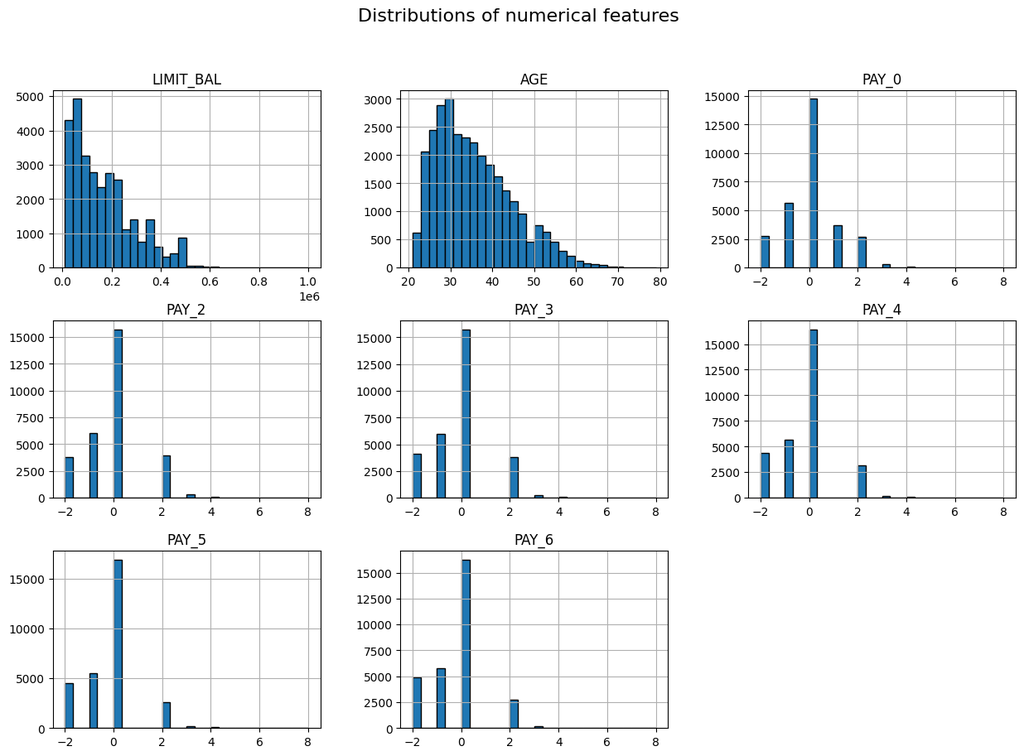

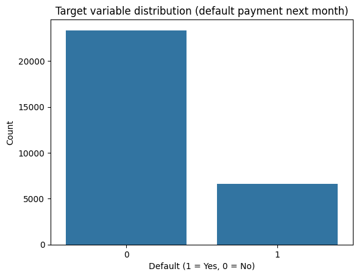

```
Correlation with target variable:

default.payment.next.month    1.000000
PAY_0                         0.324794
PAY_2                         0.263551
PAY_3                         0.235253
PAY_4                         0.216614
PAY_5                         0.204149
PAY_6                         0.186866
EDUCATION                     0.028006
AGE                           0.013890
BILL_AMT6                    -0.005372
Name: default.payment.next.month, dtype: float64
```

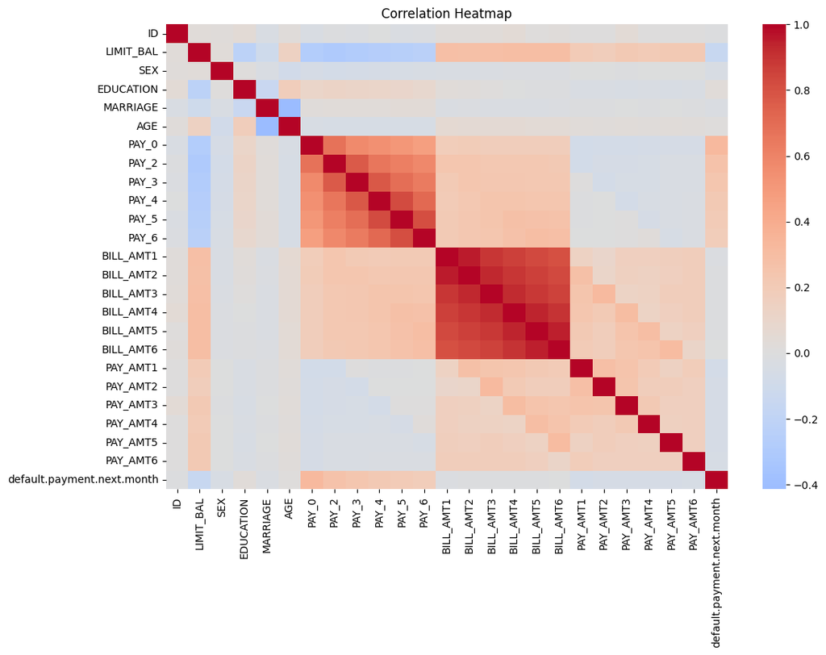

```
- The dataset contains 30,000 records and 25 variables.
- No missing values were detected.
- 22.1% of clients defaulted on their payment next month (imbalanced target).
- Variables such as PAY_0 to PAY_6, LIMIT_BAL, and BILL_AMT1-6 show strong variance.
- Some categorical features (EDUCATION, MARRIAGE) contain out-of-range values (e.g., 0, 5, 6).
- PAY_0 (most recent payment delay) shows the strongest correlation with default risk.
```

```python
# Question 1: Descriptive analysis of your data

# STEP 1 - Load the dataset

import pandas as pd
import matplotlib.pyplot as plt
import seaborn as sns

# Display settings
pd.set_option('display.max_columns', None)

# Load dataset
df = pd.read_csv("UCI_Credit_Card.csv")

# Basic info
print("Shape of dataset:", df.shape)
print("\nDataset information:")
df.info()

# Display first rows
df.head()

# STEP 2 - Descriptive statistics

# Basic statistics for numerical columns
desc = df.describe().T
display(desc)

# Check for missing values
print("\nMissing values per column:")
print(df.isnull().sum())

# Check unique values for categorical variables
cat_vars = ["SEX", "EDUCATION", "MARRIAGE"]
for col in cat_vars:
    print(f"\n{col} value counts:")
    print(df[col].value_counts())


# STEP 3 - Distributions and histograms

num_features = ["LIMIT_BAL", "AGE"] + [f"PAY_{i}" for i in range(0,7) if f"PAY_{i}" in df.columns]

# Histograms
df[num_features].hist(figsize=(15,10), bins=30, edgecolor='black')
plt.suptitle("Distributions of numerical features", fontsize=16)
plt.show()

# Distribution of the target
sns.countplot(x="default.payment.next.month", data=df)
plt.title("Target variable distribution (default payment next month)")
plt.xlabel("Default (1 = Yes, 0 = No)")
plt.ylabel("Count")
plt.show()


# STEP 4 - Correlation analysis

# Compute correlation matrix
corr_matrix = df.corr(numeric_only=True)

# Display correlation with the target variable
target_corr = corr_matrix["default.payment.next.month"].sort_values(ascending=False)
print("Correlation with target variable:\n")
print(target_corr.head(10))

# Heatmap
plt.figure(figsize=(12,8))
sns.heatmap(corr_matrix, cmap="coolwarm", center=0)
plt.title("Correlation Heatmap")
plt.show()


# STEP 5 - Summary of findings

print("""
- The dataset contains 30,000 records and 25 variables.
- No missing values were detected.
- 22.1% of clients defaulted on their payment next month (imbalanced target).
- Variables such as PAY_0 to PAY_6, LIMIT_BAL, and BILL_AMT1-6 show strong variance.
- Some categorical features (EDUCATION, MARRIAGE) contain out-of-range values (e.g., 0, 5, 6).
- PAY_0 (most recent payment delay) shows the strongest correlation with default risk.
""")
```

```python
# Question 2: Implementation of the necessary pre-processing

# STEP 1 - Cleaning categorical features

# Check unique values before cleaning
print("Unique values before cleaning:")
for col in ["EDUCATION", "MARRIAGE"]:
    print(f"{col}: {sorted(df[col].unique())}")

# Recode incorrect values
df["EDUCATION"] = df["EDUCATION"].replace({0: 4, 5: 4, 6: 4})  # Group unknowns (0,5,6) into 4 = 'Other'
df["MARRIAGE"] = df["MARRIAGE"].replace({0: 3})                # Replace 0 by 3 = 'Other'

# Check after cleaning
print("\nUnique values after cleaning:")
for col in ["EDUCATION", "MARRIAGE"]:
    print(f"{col}: {sorted(df[col].unique())}")


# STEP 2 - Separate features and target

# Target variable
target = "default.payment.next.month"

# Drop identifier
X = df.drop(columns=["ID", target])
y = df[target]

print("X shape:", X.shape)
print("y shape:", y.shape)

# STEP 3 - Feature scaling (Standardization)

from sklearn.preprocessing import StandardScaler

# Instantiate scaler
scaler = StandardScaler()

# Fit and transform
X_scaled = scaler.fit_transform(X)

# Convert back to DataFrame for readability
X_scaled = pd.DataFrame(X_scaled, columns=X.columns)

print("Scaled feature sample:")
X_scaled.head()


# STEP 4 - Encoding categorical features

# In this dataset, categorical features are already numeric (SEX, EDUCATION, MARRIAGE, PAY_X)
# So no need for one-hot encoding. But we can cast them as categorical if needed.
categorical_features = ["SEX", "EDUCATION", "MARRIAGE"]

for col in categorical_features:
    X_scaled[col] = X_scaled[col].astype("category")

print("Categorical features encoded as categories (no dummy variables created).")


# SETP 5 - Split the dataset

from sklearn.model_selection import train_test_split

# Split data (70% training, 30% testing)
X_train, X_test, y_train, y_test = train_test_split(
    X_scaled, y, test_size=0.3, random_state=42, stratify=y
)

print(f"Training set size: {X_train.shape}")
print(f"Test set size: {X_test.shape}")


# STEP 6 - Final preprocessing summary

print("""
Preprocessing completed successfully:

- Categorical anomalies fixed (EDUCATION, MARRIAGE)
- ID column removed
- Data normalized with StandardScaler
- Train/Test split performed (70/30)
- Dataset ready for model training
""")
```

```
Unique values before cleaning:
EDUCATION: [np.int64(0), np.int64(1), np.int64(2), np.int64(3), np.int64(4), np.int64(5), np.int64(6)]
MARRIAGE: [np.int64(0), np.int64(1), np.int64(2), np.int64(3)]

Unique values after cleaning:
EDUCATION: [np.int64(1), np.int64(2), np.int64(3), np.int64(4)]
MARRIAGE: [np.int64(1), np.int64(2), np.int64(3)]
X shape: (30000, 23)
y shape: (30000,)
Scaled feature sample:
Categorical features encoded as categories (no dummy variables created).
Training set size: (21000, 23)
Test set size: (9000, 23)

Preprocessing completed successfully:

- Categorical anomalies fixed (EDUCATION, MARRIAGE)
- ID column removed
- Data normalized with StandardScaler
- Train/Test split performed (70/30)
- Dataset ready for model training
```

```
Problem formalisation:

The goal is to predict whether a client will default on their next credit card payment.

- Target variable: `default.payment.next.month`
    ➤ 1 = client will default
    ➤ 0 = client will not default

- Input features (X):
    ➤ Demographic data (SEX, AGE, EDUCATION, MARRIAGE)
    ➤ Credit information (LIMIT_BAL)
    ➤ Past payment history (PAY_0 to PAY_6)
    ➤ Billing and payment amounts (BILL_AMT1-6, PAY_AMT1-6)

This is a **supervised binary classification problem**.

Categorical features: ['SEX', 'EDUCATION', 'MARRIAGE']
Numerical features: ['LIMIT_BAL', 'AGE', 'PAY_0', 'PAY_2', 'PAY_3', 'PAY_4', 'PAY_5', 'PAY_6', 'BILL_AMT1', 'BILL_AMT2'] ...
Target distribution (%):
 default.payment.next.month
0    77.88
1    22.12
Name: proportion, dtype: float64
```

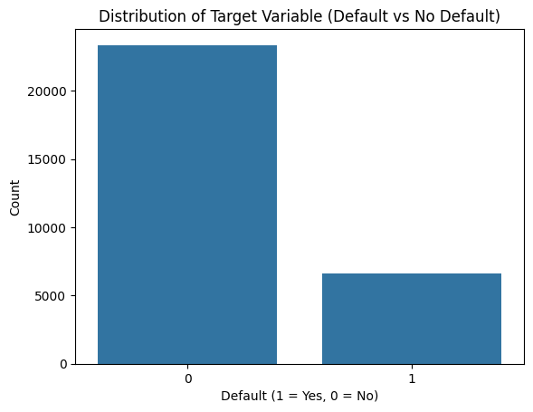

```python
# Question 3: Problem formalisation

# STEP 1 - Understanding the task

print("""
Problem formalisation:

The goal is to predict whether a client will default on their next credit card payment.

- Target variable: `default.payment.next.month`
    ➤ 1 = client will default
    ➤ 0 = client will not default

- Input features (X):
    ➤ Demographic data (SEX, AGE, EDUCATION, MARRIAGE)
    ➤ Credit information (LIMIT_BAL)
    ➤ Past payment history (PAY_0 to PAY_6)
    ➤ Billing and payment amounts (BILL_AMT1-6, PAY_AMT1-6)

This is a **supervised binary classification problem**.
""")


# STEP 2 - Variable types

categorical_features = ["SEX", "EDUCATION", "MARRIAGE"]
numerical_features = [col for col in X_scaled.columns if col not in categorical_features]

print("Categorical features:", categorical_features)
print("Numerical features:", numerical_features[:10], "...")


# STEP 3 - Target imbalance

import matplotlib.pyplot as plt
import seaborn as sns

# Calcul du pourcentage de chaque classe (0 = pas de défaut, 1 = défaut)
target_distribution = y.value_counts(normalize=True) * 100
print("Target distribution (%):\n", target_distribution)

# Visualisation de la répartition des classes
sns.countplot(x=y)
plt.title("Distribution of Target Variable (Default vs No Default)")
plt.xlabel("Default (1 = Yes, 0 = No)")
plt.ylabel("Count")
plt.show()
```

Observation: There is a clear imbalance in the dataset:

- Around 78% of clients do NOT default
- Around 22% of clients DO default

This imbalance must be taken into account during model training (using class weights or resampling).

Since the dataset is imbalanced, accuracy alone is not sufficient.

We will use the following evaluation metrics:

- **Accuracy**: general performance of the model
- **Precision**: proportion of predicted defaults that are correct
- **Recall (Sensitivity)**: ability to detect true defaults
- **F1-score**: balance between precision and recall
- **ROC-AUC**: overall discriminatory power of the model

These metrics are especially useful for **imbalanced binary classification**.

Problem Summary:

- Type of problem: Supervised learning (Binary Classification)
- Target variable: default.payment.next.month
- Input: 23 explanatory variables (credit, demographic, and payment history)
- Evaluation metrics: Accuracy, Precision, Recall, F1-score, ROC-AUC
- Specific challenge: Class imbalance (78% vs 22%)

```
Baseline Model Choice: Logistic Regression

Justification:
- Simple, interpretable and fast to train
- Well-suited for binary classification problems
- Provides probability outputs for ROC-AUC evaluation
- Serves as a reference for more advanced models (e.g., Random Forest, XGBoost)

We'll train it using the preprocessed and scaled dataset (X_train, y_train).

Logistic Regression model trained successfully.

Model Performance (Baseline - Logistic Regression):
-----------------------------------------------------
Accuracy   : 0.684
Precision  : 0.373
Recall     : 0.629
F1-score   : 0.468
ROC-AUC    : 0.716
```

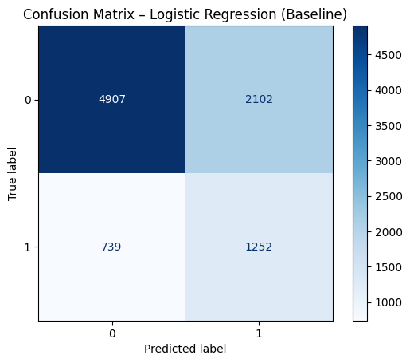

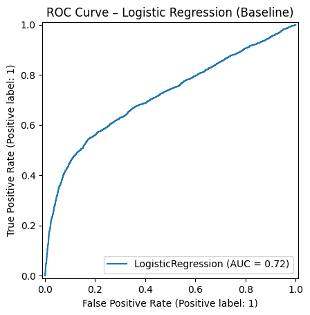

[output not shown]

```python
# Question 4: Baseline model

# STEP 1 - Model selection rationale

print("""
Baseline Model Choice: Logistic Regression

Justification:
- Simple, interpretable and fast to train
- Well-suited for binary classification problems
- Provides probability outputs for ROC-AUC evaluation
- Serves as a reference for more advanced models (e.g., Random Forest, XGBoost)

We'll train it using the preprocessed and scaled dataset (X_train, y_train).
""")


# -STEP 2 - Train logistic regression baseline model

from sklearn.linear_model import LogisticRegression

# Initialize model (with class weights to handle imbalance)
log_reg = LogisticRegression(max_iter=1000, class_weight='balanced', random_state=42)

# Train model
log_reg.fit(X_train, y_train)

# Predictions
y_pred = log_reg.predict(X_test)
y_proba = log_reg.predict_proba(X_test)[:, 1]

print("Logistic Regression model trained successfully.")


# STEP 3 - Evaluate baseline model

from sklearn.metrics import accuracy_score, precision_score, recall_score, f1_score, roc_auc_score, confusion_matrix, ConfusionMatrixDisplay

# Compute metrics
acc = accuracy_score(y_test, y_pred)
prec = precision_score(y_test, y_pred)
rec = recall_score(y_test, y_pred)
f1 = f1_score(y_test, y_pred)
roc_auc = roc_auc_score(y_test, y_proba)

print(f"""
Model Performance (Baseline - Logistic Regression):
-----------------------------------------------------
Accuracy   : {acc:.3f}
Precision  : {prec:.3f}
Recall     : {rec:.3f}
F1-score   : {f1:.3f}
ROC-AUC    : {roc_auc:.3f}
""")

# Confusion matrix
ConfusionMatrixDisplay.from_estimator(log_reg, X_test, y_test, cmap='Blues')
plt.title("Confusion Matrix – Logistic Regression (Baseline)")
plt.show()


# STEP 4 - ROC curve

from sklearn.metrics import RocCurveDisplay

RocCurveDisplay.from_estimator(log_reg, X_test, y_test)
plt.title("ROC Curve – Logistic Regression (Baseline)")
plt.show()
```

Baseline Model Summary:

- Model: Logistic Regression (balanced class weights)
- Type: Linear classifier for binary classification
- Output: Probability of default (0–1)
- Metrics show moderate recall and precision — a good starting point.
- The ROC-AUC score gives an idea of overall discriminative power.

Next steps could include:

- Trying more complex models (Random Forest, XGBoost)
- Hyperparameter tuning
- Managing imbalance (SMOTE, undersampling)
- Feature selection / engineering

========== Desicion tree ==========

```
=== Decision Tree – performances ===
Accuracy  : 0.752
Precision : 0.453
Recall    : 0.587
F1-score  : 0.511
ROC-AUC   : 0.741
```

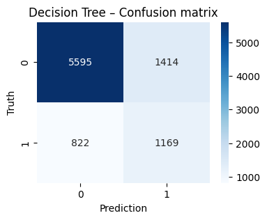

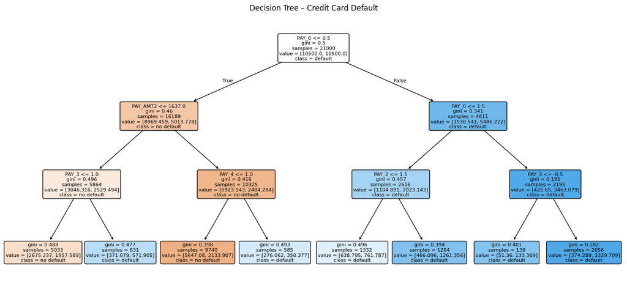

```python
# STEP 3 : Advanced model – Decision Tree

from sklearn.model_selection import train_test_split
from sklearn.tree import DecisionTreeClassifier, plot_tree
from sklearn.metrics import (
    accuracy_score, precision_score, recall_score,
    f1_score, roc_auc_score, confusion_matrix
)
import matplotlib.pyplot as plt
import seaborn as sns

# 1) Definition X/y + split=
X = df.drop(columns=["ID", "default.payment.next.month"])
y = df["default.payment.next.month"]

X_train, X_test, y_train, y_test = train_test_split(
    X, y,
    test_size=0.3,
    random_state=42,
    stratify=y
)

# 2) Decision Tree
dt_clf = DecisionTreeClassifier(
    criterion="gini",
    max_depth=3,             # depth limit
    min_samples_leaf=20,     # minimum number of examples per sheet
    class_weight="balanced", # takes into account the 0/1 imbalance
    random_state=42
)

dt_clf.fit(X_train, y_train)

# 3) Evaluation of the test game
y_pred = dt_clf.predict(X_test)
y_proba = dt_clf.predict_proba(X_test)[:, 1]

accuracy  = accuracy_score(y_test, y_pred)
precision = precision_score(y_test, y_pred)
recall    = recall_score(y_test, y_pred)
f1        = f1_score(y_test, y_pred)
roc_auc   = roc_auc_score(y_test, y_proba)

print("=== Decision Tree – performances ===")
print(f"Accuracy  : {accuracy:.3f}")
print(f"Precision : {precision:.3f}")
print(f"Recall    : {recall:.3f}")
print(f"F1-score  : {f1:.3f}")
print(f"ROC-AUC   : {roc_auc:.3f}")

# 4)  confusion matrice
cm = confusion_matrix(y_test, y_pred)
plt.figure(figsize=(4, 3))
sns.heatmap(cm, annot=True, fmt="d", cmap="Blues")
plt.xlabel("Prediction")
plt.ylabel("Truth")
plt.title("Decision Tree – Confusion matrix")
plt.show()

# 5) Visualisation
plt.figure(figsize=(18, 8))
plot_tree(
    dt_clf,
    feature_names=X.columns,
    class_names=["no default", "default"],
    filled=True,
    rounded=True,
    max_depth=3   # only the first 3 levels are displayed for readability
)
plt.title("Decision Tree – Credit Card Default")
plt.show()
```

========== Decision tree avec randomized search ==========

```
Fitting 5 folds for each of 50 candidates, totalling 250 fits
Meilleurs hyperparamètres trouvés :
{'class_weight': 'balanced', 'criterion': 'entropy', 'max_depth': 4, 'min_samples_leaf': 6, 'min_samples_split': 55}
Meilleur score CV (métrique f1) : 0.532

=== Decision Tree amélioré (RandomizedSearchCV) – performances sur le test set ===
Accuracy  : 0.774
Precision : 0.491
Recall    : 0.550
F1-score  : 0.519
ROC-AUC   : 0.751
```

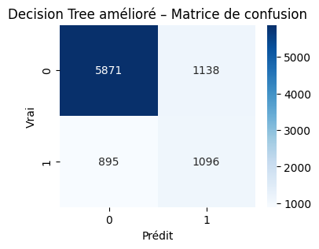

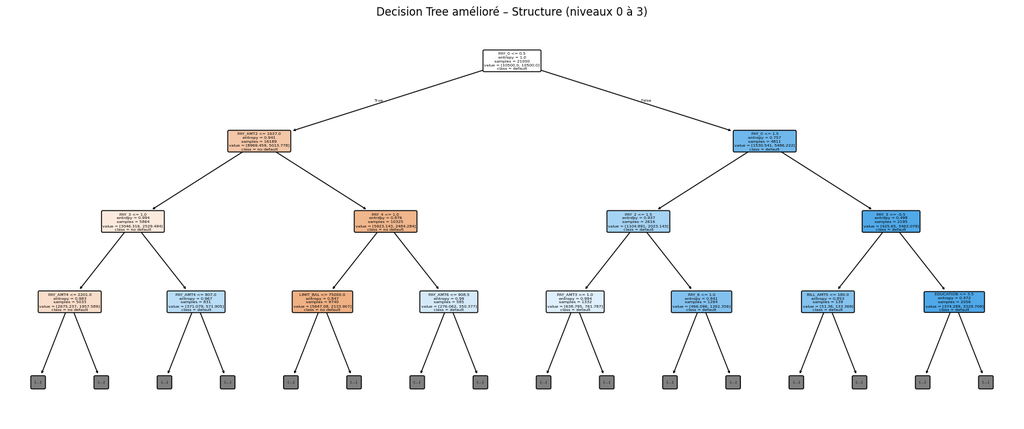

```python
# Improved Decision Tree with RandomizedSearchCV

from sklearn.model_selection import train_test_split, RandomizedSearchCV
from sklearn.tree import DecisionTreeClassifier, plot_tree
from sklearn.metrics import (
    accuracy_score, precision_score, recall_score,
    f1_score, roc_auc_score, confusion_matrix
)
from scipy.stats import randint
import seaborn as sns
import matplotlib.pyplot as plt

X = df.drop(columns=["ID", "default.payment.next.month"])
y = df["default.payment.next.month"]

X_train, X_test, y_train, y_test = train_test_split(
    X, y,
    test_size=0.3,
    random_state=42,
    stratify=y
)

# Basic model
dt = DecisionTreeClassifier(random_state=42)

#  Hyperparameter search space
param_distributions = {
    "criterion": ["gini", "entropy"],
    # we use ranges rather than fixed values
    "max_depth": [3, 4, 5, 6, 8, None],
    "min_samples_split": randint(2, 101),    # 2 to 100
    "min_samples_leaf": randint(1, 101),     # 1 to 100
    "class_weight": [None, "balanced"]
}

# RandomizedSearchCV with cross-validation
random_search = RandomizedSearchCV(
    estimator=dt,
    param_distributions=param_distributions,
    n_iter=50,            # number of randomly drawn combinations
    scoring="f1",
    cv=5,
    n_jobs=-1,
    random_state=42,
    verbose=1
)

random_search.fit(X_train, y_train)

print("Meilleurs hyperparamètres trouvés :")
print(random_search.best_params_)
print(f"Meilleur score CV (métrique f1) : {random_search.best_score_:.3f}")

# We get the best model
best_dt = random_search.best_estimator_

# Evaluation on the test set
y_pred = best_dt.predict(X_test)
y_proba = best_dt.predict_proba(X_test)[:, 1]

accuracy  = accuracy_score(y_test, y_pred)
precision = precision_score(y_test, y_pred)
recall    = recall_score(y_test, y_pred)
f1        = f1_score(y_test, y_pred)
roc_auc   = roc_auc_score(y_test, y_proba)

print("\n=== Decision Tree amélioré (RandomizedSearchCV) – performances sur le test set ===")
print(f"Accuracy  : {accuracy:.3f}")
print(f"Precision : {precision:.3f}")
print(f"Recall    : {recall:.3f}")
print(f"F1-score  : {f1:.3f}")
print(f"ROC-AUC   : {roc_auc:.3f}")

# Confusion matrix
cm = confusion_matrix(y_test, y_pred)
plt.figure(figsize=(4, 3))
sns.heatmap(cm, annot=True, fmt="d", cmap="Blues")
plt.xlabel("Prédit")
plt.ylabel("Vrai")
plt.title("Decision Tree amélioré – Matrice de confusion")
plt.show()

# Tree visualization (truncated for readability)
plt.figure(figsize=(20, 8))
plot_tree(
    best_dt,
    feature_names=X.columns,
    class_names=["no default", "default"],
    filled=True,
    rounded=True,
    max_depth=3   # only the first 3 levels are displayed
)
plt.title("Decision Tree amélioré – Structure (niveaux 0 à 3)")
plt.show()
```

============= SVM Baseline ===========

```
=== SVM (baseline) – performances sur le test set ===
Accuracy  : 0.779
Precision : 0.000
Recall    : 0.000
F1-score  : 0.000
ROC-AUC   : 0.585
```

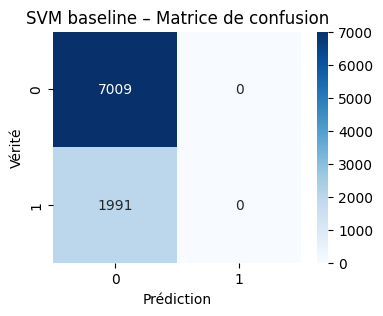

```python
# SVM (baseline)

from sklearn.svm import SVC
from sklearn.model_selection import train_test_split
from sklearn.metrics import (
    accuracy_score, precision_score, recall_score,
    f1_score, roc_auc_score, confusion_matrix
)
import seaborn as sns
import matplotlib.pyplot as plt

X = df.drop(columns=["ID", "default.payment.next.month"])
y = df["default.payment.next.month"]

X_train, X_test, y_train, y_test = train_test_split(
    X, y,
    test_size=0.3,
    random_state=42,
    stratify=y
)

# Basic SVM (default RBF kernel)
svm_clf = SVC(
    kernel="rbf",
    probability=True,   # required for ROC curves and predict_proba
    random_state=42
)

svm_clf.fit(X_train, y_train)

# Evaluation of the test game
y_pred = svm_clf.predict(X_test)
y_proba = svm_clf.predict_proba(X_test)[:, 1]

accuracy  = accuracy_score(y_test, y_pred)
precision = precision_score(y_test, y_pred)
recall    = recall_score(y_test, y_pred)
f1        = f1_score(y_test, y_pred)
roc_auc   = roc_auc_score(y_test, y_proba)

print("=== SVM (baseline) – performances sur le test set ===")
print(f"Accuracy  : {accuracy:.3f}")
print(f"Precision : {precision:.3f}")
print(f"Recall    : {recall:.3f}")
print(f"F1-score  : {f1:.3f}")
print(f"ROC-AUC   : {roc_auc:.3f}")

# Confusion matrix
cm = confusion_matrix(y_test, y_pred)
plt.figure(figsize=(4, 3))
sns.heatmap(cm, annot=True, fmt="d", cmap="Blues")
plt.xlabel("Prédiction")
plt.ylabel("Vérité")
plt.title("SVM baseline – Matrice de confusion")
plt.show()
```

=========== SVM Advanced ===============

```
Fitting 3 folds for each of 10 candidates, totalling 30 fits
Meilleurs hyperparamètres trouvés :
{'kernel': 'rbf', 'gamma': 'scale', 'class_weight': 'balanced', 'C': 1}
Meilleur score CV (f1) : 0.409

=== SVM optimisé (RandomizedSearch) – performances sur le test set ===
Accuracy  : 0.577
Precision : 0.296
Recall    : 0.661
F1-score  : 0.409
ROC-AUC   : 0.654
```

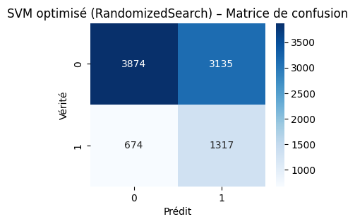

```python
# SVM advanced

from sklearn.svm import SVC
from sklearn.model_selection import train_test_split, RandomizedSearchCV
from sklearn.metrics import (
    accuracy_score, precision_score, recall_score,
    f1_score, roc_auc_score, confusion_matrix
)
import seaborn as sns
import matplotlib.pyplot as plt

X = df.drop(columns=["ID", "default.payment.next.month"])
y = df["default.payment.next.month"]

X_train, X_test, y_train, y_test = train_test_split(
    X, y,
    test_size=0.3,
    random_state=42,
    stratify=y
)

# Definition of the basic model
svm = SVC(
    probability=True,
    random_state=42
)

# Hyperparameter space
param_dist = {
    "kernel": ["rbf"],                     # RBF only to reduce costs
    "C": [0.5, 1, 2, 5, 10],               # regularization
    "gamma": ["scale", "auto", 0.1, 0.01], # influence of points
    "class_weight": [None, "balanced"]     # consideration of imbalance
}

# 4) RandomizedSearchCV
random_search = RandomizedSearchCV(
    estimator=svm,
    param_distributions=param_dist,
    n_iter=10,          # number of combinations tested
    scoring="f1",       # primary metric
    cv=3,               # 3-fold CV to reduce time
    n_jobs=-1,
    verbose=1,
    random_state=42
)

random_search.fit(X_train, y_train)

print("Meilleurs hyperparamètres trouvés :")
print(random_search.best_params_)
print(f"Meilleur score CV (f1) : {random_search.best_score_:.3f}")

# Best model
best_svm = random_search.best_estimator_

# Evaluation of the test game
y_pred = best_svm.predict(X_test)
y_proba = best_svm.predict_proba(X_test)[:, 1]

accuracy  = accuracy_score(y_test, y_pred)
precision = precision_score(y_test, y_pred)
recall    = recall_score(y_test, y_pred)
f1        = f1_score(y_test, y_pred)
roc_auc   = roc_auc_score(y_test, y_proba)

print("\n=== SVM optimisé (RandomizedSearch) – performances sur le test set ===")
print(f"Accuracy  : {accuracy:.3f}")
print(f"Precision : {precision:.3f}")
print(f"Recall    : {recall:.3f}")
print(f"F1-score  : {f1:.3f}")
print(f"ROC-AUC   : {roc_auc:.3f}")

# confusion matrix
cm = confusion_matrix(y_test, y_pred)
plt.figure(figsize=(4, 3))
sns.heatmap(cm, annot=True, fmt="d", cmap="Blues")
plt.xlabel("Prédit")
plt.ylabel("Vérité")
plt.title("SVM optimisé (RandomizedSearch) – Matrice de confusion")
plt.show()
```

========= KNN Baseline =========

```
=== KNN baseline – Test set performance ===
Accuracy  : 0.753
Precision : 0.374
Recall    : 0.175
F1-score  : 0.239
ROC-AUC   : 0.606
```

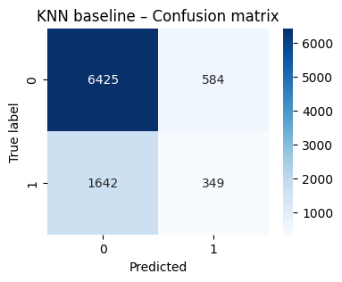

```python
# KNN baseline

from sklearn.neighbors import KNeighborsClassifier
from sklearn.model_selection import train_test_split
from sklearn.metrics import (
    accuracy_score, precision_score, recall_score,
    f1_score, roc_auc_score, confusion_matrix
)
import seaborn as sns
import matplotlib.pyplot as plt

# Define X / y + train-test split
X = df.drop(columns=["ID", "default.payment.next.month"])
y = df["default.payment.next.month"]

X_train, X_test, y_train, y_test = train_test_split(
    X, y,
    test_size=0.3,          # 30% test set
    random_state=42,
    stratify=y              # keeps the class distribution balanced across splits
)

# KNN baseline model (using default hyperparameters)
# KNN works by comparing each point with its k nearest neighbors.
# Default k=5, distance = Euclidean.
knn = KNeighborsClassifier()

knn.fit(X_train, y_train)

# Model evaluation on the test set
y_pred = knn.predict(X_test)

# Some KNN configurations allow predict_proba, others do not
try:
    y_proba = knn.predict_proba(X_test)[:, 1]
except:
    y_proba = None

accuracy  = accuracy_score(y_test, y_pred)
precision = precision_score(y_test, y_pred)
recall    = recall_score(y_test, y_pred)
f1        = f1_score(y_test, y_pred)

print("=== KNN baseline – Test set performance ===")
print(f"Accuracy  : {accuracy:.3f}")
print(f"Precision : {precision:.3f}")
print(f"Recall    : {recall:.3f}")
print(f"F1-score  : {f1:.3f}")

if y_proba is not None:
    roc_auc = roc_auc_score(y_test, y_proba)
    print(f"ROC-AUC   : {roc_auc:.3f}")

# Confusion matrix (shows the true vs predicted classes)
cm = confusion_matrix(y_test, y_pred)
plt.figure(figsize=(4,3))
sns.heatmap(cm, annot=True, fmt="d", cmap="Blues")
plt.xlabel("Predicted")
plt.ylabel("True label")
plt.title("KNN baseline – Confusion matrix")
plt.show()
```

=========== Advanced KNN ===========

```
Fitting 3 folds for each of 20 candidates, totalling 60 fits
Best hyperparameters found:
{'weights': 'uniform', 'p': 1, 'n_neighbors': np.int64(3)}
Best CV score (F1) : 0.271

=== KNN optimized – Test set performance ===
Accuracy  : 0.736
Precision : 0.349
Recall    : 0.226
F1-score  : 0.274
ROC-AUC   : 0.601
```

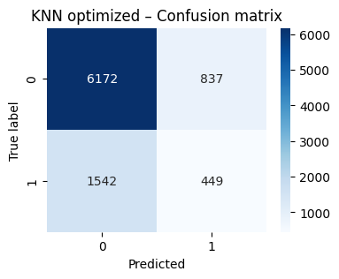

```python
# KNN optimized (RandomizedSearch)

from sklearn.neighbors import KNeighborsClassifier
from sklearn.model_selection import RandomizedSearchCV
from sklearn.metrics import (
    accuracy_score, precision_score, recall_score,
    f1_score, roc_auc_score, confusion_matrix
)
import seaborn as sns
import matplotlib.pyplot as plt
import numpy as np

# Define X / y + split
X = df.drop(columns=["ID", "default.payment.next.month"])
y = df["default.payment.next.month"]

X_train, X_test, y_train, y_test = train_test_split(
    X, y,
    test_size=0.3,
    random_state=42,
    stratify=y
)

# Base KNN model
# We optimize this model using RandomizedSearchCV.
knn = KNeighborsClassifier()

# Hyperparameter search space
# n_neighbors : number of neighbors considered (K)
# weights     : "uniform" = all neighbors have equal weight,
#               "distance" = closer neighbors have more influence
# p           : distance metric (1=Manhattan, 2=Euclidean)
param_dist = {
    "n_neighbors": np.arange(3, 30),
    "weights": ["uniform", "distance"],
    "p": [1, 2]
}

# RandomizedSearchCV
# Randomized search tries a limited number of random combinations,
# much faster than GridSearch (which tries every single combination).
random_search = RandomizedSearchCV(
    estimator=knn,
    param_distributions=param_dist,
    n_iter=20,          # number of random combinations to test
    scoring="f1",       # F1-score = good metric for imbalanced data
    cv=3,               # 3-fold cross-validation (faster than cv=5)
    n_jobs=-1,          # use all CPU cores
    verbose=1,
    random_state=42
)

random_search.fit(X_train, y_train)

print("Best hyperparameters found:")
print(random_search.best_params_)
print(f"Best CV score (F1) : {random_search.best_score_:.3f}")

# Retrieve the best model found during search
best_knn = random_search.best_estimator_

# Evaluation on the test set
y_pred = best_knn.predict(X_test)

try:
    y_proba = best_knn.predict_proba(X_test)[:, 1]
except:
    y_proba = None

accuracy  = accuracy_score(y_test, y_pred)
precision = precision_score(y_test, y_pred)
recall    = recall_score(y_test, y_pred)
f1        = f1_score(y_test, y_pred)

print("\n=== KNN optimized – Test set performance ===")
print(f"Accuracy  : {accuracy:.3f}")
print(f"Precision : {precision:.3f}")
print(f"Recall    : {recall:.3f}")
print(f"F1-score  : {f1:.3f}")

if y_proba is not None:
    roc_auc = roc_auc_score(y_test, y_proba)
    print(f"ROC-AUC   : {roc_auc:.3f}")

# Confusion matrix
cm = confusion_matrix(y_test, y_pred)
plt.figure(figsize=(4,3))
sns.heatmap(cm, annot=True, fmt="d", cmap="Blues")
plt.xlabel("Predicted")
plt.ylabel("True label")
plt.title("KNN optimized – Confusion matrix")
plt.show()
```

=========== Random Forest Baseline =============

```
=== Random Forest baseline – Test set performance ===
Accuracy  : 0.816
Precision : 0.646
Recall    : 0.370
F1-score  : 0.470
ROC-AUC   : 0.759
```

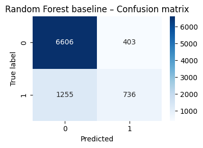

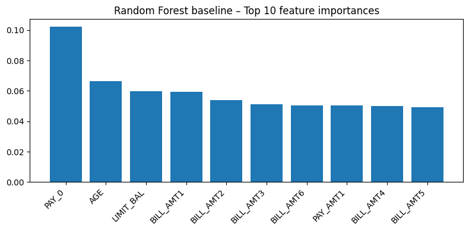

```python
# Random Forest baseline

from sklearn.ensemble import RandomForestClassifier
from sklearn.model_selection import train_test_split
from sklearn.metrics import (
    accuracy_score, precision_score, recall_score,
    f1_score, roc_auc_score, confusion_matrix
)
import seaborn as sns
import matplotlib.pyplot as plt

# Define X / y + train-test split
X = df.drop(columns=["ID", "default.payment.next.month"])
y = df["default.payment.next.month"]

X_train, X_test, y_train, y_test = train_test_split(
    X, y,
    test_size=0.3,
    random_state=42,
    stratify=y          # keeps the same class ratio in train and test
)

# Baseline Random Forest model
# Random Forest = ensemble of decision trees (bagging)
rf_baseline = RandomForestClassifier(
    n_estimators=200,   # number of trees in the forest
    random_state=42,
    n_jobs=-1           # use all available CPU cores
)

rf_baseline.fit(X_train, y_train)

# Evaluation on the test set
y_pred = rf_baseline.predict(X_test)
y_proba = rf_baseline.predict_proba(X_test)[:, 1]

accuracy  = accuracy_score(y_test, y_pred)
precision = precision_score(y_test, y_pred)
recall    = recall_score(y_test, y_pred)
f1        = f1_score(y_test, y_pred)
roc_auc   = roc_auc_score(y_test, y_proba)

print("=== Random Forest baseline – Test set performance ===")
print(f"Accuracy  : {accuracy:.3f}")
print(f"Precision : {precision:.3f}")
print(f"Recall    : {recall:.3f}")
print(f"F1-score  : {f1:.3f}")
print(f"ROC-AUC   : {roc_auc:.3f}")

# Confusion matrix
cm = confusion_matrix(y_test, y_pred)
plt.figure(figsize=(4, 3))
sns.heatmap(cm, annot=True, fmt="d", cmap="Blues")
plt.xlabel("Predicted")
plt.ylabel("True label")
plt.title("Random Forest baseline – Confusion matrix")
plt.tight_layout()
plt.show()

# (Optional) Feature importance plot for interpretation
importances = rf_baseline.feature_importances_
indices = np.argsort(importances)[::-1][:10]  # top 10 features

plt.figure(figsize=(8, 4))
plt.bar(range(len(indices)), importances[indices])
plt.xticks(range(len(indices)), X.columns[indices], rotation=45, ha="right")
plt.title("Random Forest baseline – Top 10 feature importances")
plt.tight_layout()
plt.show()
```

=========== Random Forest Advanced =============

```
Fitting 3 folds for each of 20 candidates, totalling 60 fits
Best hyperparameters found for Random Forest:
{'n_estimators': 600, 'min_samples_split': 50, 'min_samples_leaf': 20, 'max_features': 'sqrt', 'max_depth': 15, 'class_weight': 'balanced'}
Best CV score (F1) : 0.546

=== Random Forest optimized – Test set performance ===
Accuracy  : 0.778
Precision : 0.498
Recall    : 0.592
F1-score  : 0.541
ROC-AUC   : 0.779
```

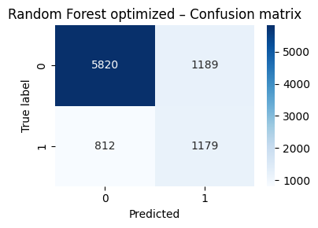

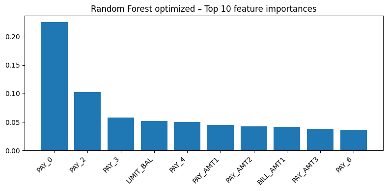

```python
# Random Forest optimized (RandomizedSearch)

from sklearn.ensemble import RandomForestClassifier
from sklearn.model_selection import RandomizedSearchCV
from sklearn.metrics import (
    accuracy_score, precision_score, recall_score,
    f1_score, roc_auc_score, confusion_matrix
)
import seaborn as sns
import matplotlib.pyplot as plt
import numpy as np

# Define X / y + train-test split
X = df.drop(columns=["ID", "default.payment.next.month"])
y = df["default.payment.next.month"]

X_train, X_test, y_train, y_test = train_test_split(
    X, y,
    test_size=0.3,
    random_state=42,
    stratify=y
)

# Base Random Forest model
rf = RandomForestClassifier(
    random_state=42,
    n_jobs=-1
)

# Hyperparameter search space
# n_estimators     : number of trees
# max_depth        : depth of each tree
# min_samples_split: min samples required to split a node
# min_samples_leaf : min samples in a leaf
# max_features     : number of features considered at each split
# class_weight     : manage class imbalance (None vs "balanced")
param_dist = {
    "n_estimators": [200, 400, 600],
    "max_depth": [None, 5, 10, 15],
    "min_samples_split": [2, 10, 50],
    "min_samples_leaf": [1, 5, 20],
    "max_features": ["sqrt", "log2", 0.5],
    "class_weight": [None, "balanced"]
}

# RandomizedSearchCV for faster optimization
random_search_rf = RandomizedSearchCV(
    estimator=rf,
    param_distributions=param_dist,
    n_iter=20,          # number of random combinations
    scoring="f1",       # focus on F1 due to class imbalance
    cv=3,               # 3-fold cross-validation
    n_jobs=-1,
    verbose=1,
    random_state=42
)

random_search_rf.fit(X_train, y_train)

print("Best hyperparameters found for Random Forest:")
print(random_search_rf.best_params_)
print(f"Best CV score (F1) : {random_search_rf.best_score_:.3f}")

# Best model
best_rf = random_search_rf.best_estimator_

# Evaluation on the test set
y_pred = best_rf.predict(X_test)
y_proba = best_rf.predict_proba(X_test)[:, 1]

accuracy  = accuracy_score(y_test, y_pred)
precision = precision_score(y_test, y_pred)
recall    = recall_score(y_test, y_pred)
f1        = f1_score(y_test, y_pred)
roc_auc   = roc_auc_score(y_test, y_proba)

print("\n=== Random Forest optimized – Test set performance ===")
print(f"Accuracy  : {accuracy:.3f}")
print(f"Precision : {precision:.3f}")
print(f"Recall    : {recall:.3f}")
print(f"F1-score  : {f1:.3f}")
print(f"ROC-AUC   : {roc_auc:.3f}")

# Confusion matrix
cm = confusion_matrix(y_test, y_pred)
plt.figure(figsize=(4, 3))
sns.heatmap(cm, annot=True, fmt="d", cmap="Blues")
plt.xlabel("Predicted")
plt.ylabel("True label")
plt.title("Random Forest optimized – Confusion matrix")
plt.tight_layout()
plt.show()

# Feature importance plot for the optimized model
importances = best_rf.feature_importances_
indices = np.argsort(importances)[::-1][:10]

plt.figure(figsize=(8, 4))
plt.bar(range(len(indices)), importances[indices])
plt.xticks(range(len(indices)), X.columns[indices], rotation=45, ha="right")
plt.title("Random Forest optimized – Top 10 feature importances")
plt.tight_layout()
plt.show()
```

========== Gradient Boosting Baseline ===========

```
=== Gradient Boosting baseline – Test set performance ===
Accuracy  : 0.818
Precision : 0.665
Recall    : 0.357
F1-score  : 0.464
ROC-AUC   : 0.780
```

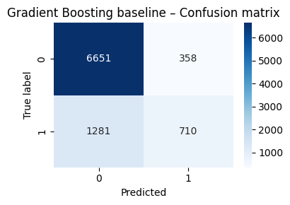

```python
# Gradient Boosting baseline

from sklearn.ensemble import GradientBoostingClassifier
from sklearn.model_selection import train_test_split
from sklearn.metrics import (
    accuracy_score, precision_score, recall_score,
    f1_score, roc_auc_score, confusion_matrix
)
import seaborn as sns
import matplotlib.pyplot as plt

# Define X / y + train-test split
X = df.drop(columns=["ID", "default.payment.next.month"])
y = df["default.payment.next.month"]

X_train, X_test, y_train, y_test = train_test_split(
    X, y,
    test_size=0.3,
    random_state=42,
    stratify=y
)

# Baseline Gradient Boosting model
# Gradient Boosting builds trees sequentially, each new tree correcting
# the errors of the previous ones.
gb_baseline = GradientBoostingClassifier(
    random_state=42
)

gb_baseline.fit(X_train, y_train)

# Evaluation on the test set
y_pred = gb_baseline.predict(X_test)
y_proba = gb_baseline.predict_proba(X_test)[:, 1]

accuracy  = accuracy_score(y_test, y_pred)
precision = precision_score(y_test, y_pred)
recall    = recall_score(y_test, y_pred)
f1        = f1_score(y_test, y_pred)
roc_auc   = roc_auc_score(y_test, y_proba)

print("=== Gradient Boosting baseline – Test set performance ===")
print(f"Accuracy  : {accuracy:.3f}")
print(f"Precision : {precision:.3f}")
print(f"Recall    : {recall:.3f}")
print(f"F1-score  : {f1:.3f}")
print(f"ROC-AUC   : {roc_auc:.3f}")

# Confusion matrix
cm = confusion_matrix(y_test, y_pred)
plt.figure(figsize=(4,3))
sns.heatmap(cm, annot=True, fmt="d", cmap="Blues")
plt.xlabel("Predicted")
plt.ylabel("True label")
plt.title("Gradient Boosting baseline – Confusion matrix")
plt.tight_layout()
plt.show()
```

========== Gradient Boosting Advanced ===========

```
Fitting 3 folds for each of 20 candidates, totalling 60 fits
Best hyperparameters found for Gradient Boosting:
{'n_estimators': 200, 'min_samples_split': 2, 'min_samples_leaf': 20, 'max_depth': 3, 'learning_rate': 0.05}
Best CV score (F1) : 0.483

=== Gradient Boosting optimized – Test set performance ===
Accuracy  : 0.818
Precision : 0.665
Recall    : 0.356
F1-score  : 0.463
ROC-AUC   : 0.778
```

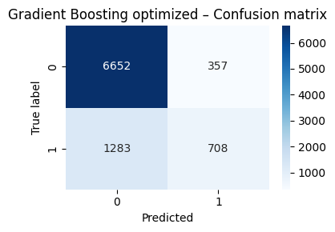

```python
# Gradient Boosting optimized (RandomizedSearch)

from sklearn.ensemble import GradientBoostingClassifier
from sklearn.model_selection import RandomizedSearchCV
from sklearn.metrics import (
    accuracy_score, precision_score, recall_score,
    f1_score, roc_auc_score, confusion_matrix
)
import seaborn as sns
import matplotlib.pyplot as plt
import numpy as np

# Define X / y + split
X = df.drop(columns=["ID", "default.payment.next.month"])
y = df["default.payment.next.month"]

X_train, X_test, y_train, y_test = train_test_split(
    X, y,
    test_size=0.3,
    random_state=42,
    stratify=y
)

# Base Gradient Boosting model
gb = GradientBoostingClassifier(random_state=42)

# Hyperparameter search space for optimization
# n_estimators    : number of boosting stages
# learning_rate   : shrinkage of each tree’s contribution
# max_depth       : depth of individual trees
# min_samples_split / leaf: regularization
param_dist = {
    "n_estimators": [100, 200, 300],
    "learning_rate": [0.01, 0.05, 0.1, 0.2],
    "max_depth": [2, 3, 4, 5],
    "min_samples_split": [2, 20, 50],
    "min_samples_leaf": [1, 10, 20]
}

# RandomizedSearchCV for faster tuning
random_search_gb = RandomizedSearchCV(
    estimator=gb,
    param_distributions=param_dist,
    n_iter=20,          # number of random combinations tested
    scoring="f1",       # F1-score = good for imbalanced datasets
    cv=3,               # faster than cv=5
    n_jobs=-1,
    verbose=1,
    random_state=42
)

random_search_gb.fit(X_train, y_train)

print("Best hyperparameters found for Gradient Boosting:")
print(random_search_gb.best_params_)
print(f"Best CV score (F1) : {random_search_gb.best_score_:.3f}")

# Best model
best_gb = random_search_gb.best_estimator_

# Evaluation on the test set
y_pred = best_gb.predict(X_test)
y_proba = best_gb.predict_proba(X_test)[:, 1]

accuracy  = accuracy_score(y_test, y_pred)
precision = precision_score(y_test, y_pred)
recall    = recall_score(y_test, y_pred)
f1        = f1_score(y_test, y_pred)
roc_auc   = roc_auc_score(y_test, y_proba)

print("\n=== Gradient Boosting optimized – Test set performance ===")
print(f"Accuracy  : {accuracy:.3f}")
print(f"Precision : {precision:.3f}")
print(f"Recall    : {recall:.3f}")
print(f"F1-score  : {f1:.3f}")
print(f"ROC-AUC   : {roc_auc:.3f}")

# Confusion matrix
cm = confusion_matrix(y_test, y_pred)
plt.figure(figsize=(4,3))
sns.heatmap(cm, annot=True, fmt="d", cmap="Blues")
plt.xlabel("Predicted")
plt.ylabel("True label")
plt.title("Gradient Boosting optimized – Confusion matrix")
plt.tight_layout()
plt.show()
```

========== XGBoost Baseline ==========

```python
!pip install xgboost
```

```
=== XGBoost baseline – Test set performance ===
Accuracy  : 0.808
Precision : 0.615
Recall    : 0.349
F1-score  : 0.445
ROC-AUC   : 0.759
```

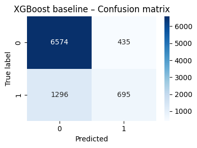

```python
# XGBoost baseline

from xgboost import XGBClassifier
from sklearn.model_selection import train_test_split
from sklearn.metrics import (
    accuracy_score, precision_score, recall_score,
    f1_score, roc_auc_score, confusion_matrix
)
import seaborn as sns
import matplotlib.pyplot as plt

# Define X / y + train-test split
X = df.drop(columns=["ID", "default.payment.next.month"])
y = df["default.payment.next.month"]

X_train, X_test, y_train, y_test = train_test_split(
    X, y,
    test_size=0.3,
    random_state=42,
    stratify=y
)

# Baseline XGBoost model (default hyperparameters)
xgb_baseline = XGBClassifier(
    objective="binary:logistic",
    eval_metric="logloss",
    use_label_encoder=False,
    random_state=42,
    n_jobs=-1
)

xgb_baseline.fit(X_train, y_train)

# Evaluation on test set
y_pred = xgb_baseline.predict(X_test)
y_proba = xgb_baseline.predict_proba(X_test)[:, 1]

accuracy  = accuracy_score(y_test, y_pred)
precision = precision_score(y_test, y_pred)
recall    = recall_score(y_test, y_pred)
f1        = f1_score(y_test, y_pred)
roc_auc   = roc_auc_score(y_test, y_proba)

print("=== XGBoost baseline – Test set performance ===")
print(f"Accuracy  : {accuracy:.3f}")
print(f"Precision : {precision:.3f}")
print(f"Recall    : {recall:.3f}")
print(f"F1-score  : {f1:.3f}")
print(f"ROC-AUC   : {roc_auc:.3f}")

# Confusion matrix
cm = confusion_matrix(y_test, y_pred)
plt.figure(figsize=(4,3))
sns.heatmap(cm, annot=True, fmt="d", cmap="Blues")
plt.xlabel("Predicted")
plt.ylabel("True label")
plt.title("XGBoost baseline – Confusion matrix")
plt.tight_layout()
plt.show()
```

========= XGBoost Advanced ==========

```
Fitting 3 folds for each of 20 candidates, totalling 60 fits
```

```
Best hyperparameters found for XGBoost:
{'subsample': 0.8, 'n_estimators': 600, 'min_child_weight': 1, 'max_depth': 4, 'learning_rate': 0.01, 'gamma': 0.1, 'colsample_bytree': 0.6}
Best CV score (F1): 0.484

=== XGBoost optimized – Test set performance ===
Accuracy  : 0.817
Precision : 0.662
Recall    : 0.352
F1-score  : 0.459
ROC-AUC   : 0.781
```

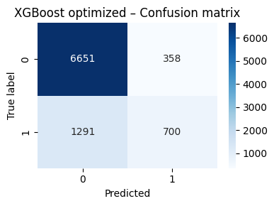

```python
# XGBoost optimized (RandomizedSearch)

from xgboost import XGBClassifier
from sklearn.model_selection import RandomizedSearchCV
from sklearn.metrics import (
    accuracy_score, precision_score, recall_score,
    f1_score, roc_auc_score, confusion_matrix
)
import seaborn as sns
import matplotlib.pyplot as plt
import numpy as np

# Define X / y + split
X = df.drop(columns=["ID", "default.payment.next.month"])
y = df["default.payment.next.month"]

X_train, X_test, y_train, y_test = train_test_split(
    X, y,
    test_size=0.3,
    random_state=42,
    stratify=y
)

# Base XGBoost model
xgb = XGBClassifier(
    objective="binary:logistic",
    eval_metric="logloss",
    use_label_encoder=False,
    n_jobs=-1,
    random_state=42
)

# Hyperparameter search space
param_dist = {
    "n_estimators": [200, 400, 600],
    "learning_rate": [0.01, 0.05, 0.1, 0.2],
    "max_depth": [3, 4, 5, 6],
    "subsample": [0.6, 0.8, 1.0],
    "colsample_bytree": [0.6, 0.8, 1.0],
    "gamma": [0, 0.1, 0.2, 1],
    "min_child_weight": [1, 5, 10]
}

# RandomizedSearch for faster tuning
random_search_xgb = RandomizedSearchCV(
    estimator=xgb,
    param_distributions=param_dist,
    n_iter=20,
    scoring="f1",
    cv=3,
    n_jobs=-1,
    verbose=1,
    random_state=42
)

random_search_xgb.fit(X_train, y_train)

print("Best hyperparameters found for XGBoost:")
print(random_search_xgb.best_params_)
print(f"Best CV score (F1): {random_search_xgb.best_score_:.3f}")

# Best model
best_xgb = random_search_xgb.best_estimator_

# Evaluation
y_pred = best_xgb.predict(X_test)
y_proba = best_xgb.predict_proba(X_test)[:, 1]

accuracy  = accuracy_score(y_test, y_pred)
precision = precision_score(y_test, y_pred)
recall    = recall_score(y_test, y_pred)
f1        = f1_score(y_test, y_pred)
roc_auc   = roc_auc_score(y_test, y_proba)

print("\n=== XGBoost optimized – Test set performance ===")
print(f"Accuracy  : {accuracy:.3f}")
print(f"Precision : {precision:.3f}")
print(f"Recall    : {recall:.3f}")
print(f"F1-score  : {f1:.3f}")
print(f"ROC-AUC   : {roc_auc:.3f}")

# Confusion matrix
cm = confusion_matrix(y_test, y_pred)
plt.figure(figsize=(4,3))
sns.heatmap(cm, annot=True, fmt="d", cmap="Blues")
plt.xlabel("Predicted")
plt.ylabel("True label")
plt.title("XGBoost optimized – Confusion matrix")
plt.tight_layout()
plt.show()
```

=========== Algorithm Outside Of The Course : MLP ===========

```
Class weights used: {0: 0.6420055029043106, 1: 2.2604951560818085}
66/66 ━━━━━━━━━━━━━━━━━━━━ 3s 13ms/step - auc: 0.5052 - loss: 7312.6987 - val_auc: 0.5724 - val_loss: 509.3837
66/66 ━━━━━━━━━━━━━━━━━━━━ 1s 7ms/step - auc: 0.5244 - loss: 1669.8737 - val_auc: 0.5334 - val_loss: 35.2956
66/66 ━━━━━━━━━━━━━━━━━━━━ 0s 4ms/step - auc: 0.5270 - loss: 482.0467 - val_auc: 0.4966 - val_loss: 2.7807
66/66 ━━━━━━━━━━━━━━━━━━━━ 0s 4ms/step - auc: 0.5120 - loss: 187.2726 - val_auc: 0.5844 - val_loss: 1.1160
66/66 ━━━━━━━━━━━━━━━━━━━━ 1s 5ms/step - auc: 0.5084 - loss: 74.6339 - val_auc: 0.4085 - val_loss: 1.2113
66/66 ━━━━━━━━━━━━━━━━━━━━ 0s 4ms/step - auc: 0.5089 - loss: 54.9291 - val_auc: 0.5939 - val_loss: 0.6068
66/66 ━━━━━━━━━━━━━━━━━━━━ 0s 5ms/step - auc: 0.5117 - loss: 45.8901 - val_auc: 0.5951 - val_loss: 0.6595
66/66 ━━━━━━━━━━━━━━━━━━━━ 0s 4ms/step - auc: 0.5215 - loss: 26.1161 - val_auc: 0.4501 - val_loss: 1.0427
66/66 ━━━━━━━━━━━━━━━━━━━━ 0s 4ms/step - auc: 0.5046 - loss: 21.7653 - val_auc: 0.4285 - val_loss: 0.8254
66/66 ━━━━━━━━━━━━━━━━━━━━ 0s 4ms/step - auc: 0.5069 - loss: 10.7468 - val_auc: 0.4220 - val_loss: 0.7905
66/66 ━━━━━━━━━━━━━━━━━━━━ 0s 4ms/step - auc: 0.5155 - loss: 8.6359 - val_auc: 0.5845 - val_loss: 0.6716
66/66 ━━━━━━━━━━━━━━━━━━━━ 0s 4ms/step - auc: 0.5019 - loss: 6.6632 - val_auc: 0.4113 - val_loss: 0.8067
282/282 ━━━━━━━━━━━━━━━━━━━━ 0s 1ms/step

=== MLP (class_weight) – Test set performance ===
Accuracy  : 0.603
Precision : 0.274
Recall    : 0.480
F1-score  : 0.349
ROC-AUC   : 0.588
```

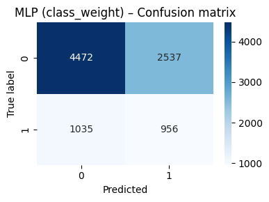

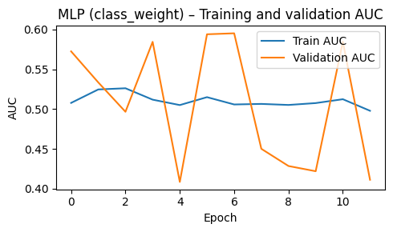

```python
# MLP (Neural Network)

import numpy as np
import tensorflow as tf
from tensorflow import keras
from tensorflow.keras import layers

from sklearn.model_selection import train_test_split
from sklearn.utils.class_weight import compute_class_weight
from sklearn.metrics import (
    accuracy_score, precision_score, recall_score,
    f1_score, roc_auc_score, confusion_matrix
)

import seaborn as sns
import matplotlib.pyplot as plt

# Define X / y + train-test split
X = df.drop(columns=["ID", "default.payment.next.month"])
y = df["default.payment.next.month"]

X_train, X_test, y_train, y_test = train_test_split(
    X, y,
    test_size=0.3,
    random_state=42,
    stratify=y
)

# Convert to numpy arrays (Keras can also work with pandas, but numpy is explicit)
X_train_np = X_train.values
X_test_np  = X_test.values
y_train_np = y_train.values
y_test_np  = y_test.values

# Compute class weights (balanced) from training labels only
# This increases the penalty for mistakes on the minority class (default = 1)
classes = np.unique(y_train_np)
weights = compute_class_weight(class_weight="balanced", classes=classes, y=y_train_np)
class_weight = {int(c): float(w) for c, w in zip(classes, weights)}
print("Class weights used:", class_weight)

# Define the MLP architecture
input_dim = X_train_np.shape[1]

model = keras.Sequential([
    layers.Input(shape=(input_dim,)),
    layers.Dense(64, activation="relu"),
    layers.Dropout(0.3),
    layers.Dense(32, activation="relu"),
    layers.Dropout(0.3),
    layers.Dense(1, activation="sigmoid")
])

# Compile the model
# AUC is more informative than accuracy on imbalanced datasets
model.compile(
    optimizer=keras.optimizers.Adam(learning_rate=0.001),
    loss="binary_crossentropy",
    metrics=[tf.keras.metrics.AUC(name="auc")]
)

# Train the model with EarlyStopping on validation AUC
early_stop = keras.callbacks.EarlyStopping(
    monitor="val_auc",
    mode="max",
    patience=5,
    restore_best_weights=True
)

history = model.fit(
    X_train_np, y_train_np,
    validation_split=0.2,
    epochs=50,
    batch_size=256,
    callbacks=[early_stop],
    class_weight=class_weight,
    verbose=1
)

# Evaluation on the test set
y_proba = model.predict(X_test_np).ravel()
y_pred = (y_proba >= 0.5).astype(int)

accuracy  = accuracy_score(y_test_np, y_pred)
precision = precision_score(y_test_np, y_pred, zero_division=0)
recall    = recall_score(y_test_np, y_pred, zero_division=0)
f1        = f1_score(y_test_np, y_pred, zero_division=0)
roc_auc   = roc_auc_score(y_test_np, y_proba)

print("\n=== MLP (class_weight) – Test set performance ===")
print(f"Accuracy  : {accuracy:.3f}")
print(f"Precision : {precision:.3f}")
print(f"Recall    : {recall:.3f}")
print(f"F1-score  : {f1:.3f}")
print(f"ROC-AUC   : {roc_auc:.3f}")

# Confusion matrix
cm = confusion_matrix(y_test_np, y_pred)
plt.figure(figsize=(4, 3))
sns.heatmap(cm, annot=True, fmt="d", cmap="Blues")
plt.xlabel("Predicted")
plt.ylabel("True label")
plt.title("MLP (class_weight) – Confusion matrix")
plt.tight_layout()
plt.show()

# Plot training history (AUC)
plt.figure(figsize=(5, 3))
plt.plot(history.history["auc"], label="Train AUC")
plt.plot(history.history["val_auc"], label="Validation AUC")
plt.xlabel("Epoch")
plt.ylabel("AUC")
plt.title("MLP (class_weight) – Training and validation AUC")
plt.legend()
plt.tight_layout()
plt.show()
```

### Analysis of the MLP results

However, the overall performance remains limited. The ROC-AUC stays low and the confusion matrix shows a large number of false positives. The training and validation AUC curves are also unstable, indicating that the network struggles to learn a reliable discriminative pattern.

Within the scope of this project, we cannot go much further, as meaningful improvements would require data normalization, dataset rebalancing, or specialized loss functions, all of which are explicitly forbidden by the project guidelines. This confirms that, under these constraints, neural networks are not well suited to this problem, while ensemble tree-based models remain the most effective.

```python
df_results = pd.DataFrame({
    "Modèle": [
        "Logistic Regression",
        "Decision Tree",
        "SVM",
        "KNN",
        "Random Forest",
        "Gradient Boost",
        "XGBoost",
        "MLP"
    ],
    "Accuracy":  [0.684, 0.774, 0.577, 0.736, 0.778, 0.818, 0.817, 0.603],
    "Precision": [0.373, 0.491, 0.296, 0.349, 0.498, 0.665, 0.662, 0.274],
    "Recall":    [0.629, 0.550, 0.661, 0.226, 0.592, 0.356, 0.352, 0.480],
    "F1-score":  [0.468, 0.519, 0.409, 0.274, 0.541, 0.463, 0.459, 0.349],
    "AUC":       [0.716, 0.752, 0.654, 0.601, 0.779, 0.778, 0.781, 0.588]
})

df_results
```

[output not shown]

### Conclusion – Step 3

The aim of Step 3 was to go beyond the standard baseline model and explore a complete improvement pipeline by testing several machine learning algorithms, then optimizing the most relevant ones for better performance on the credit default prediction task.

Logistic Regression, used as our baseline, provides reasonable performance for a linear model but cannot capture complex relationships in the data. The optimized Decision Tree improves on this but remains less stable and powerful than the ensemble models.

The best overall results are achieved by **Gradient Boosting** and **XGBoost**, which show the highest Accuracy, Precision, and AUC in our comparison table. Random Forest follows closely, offering strong performance and good robustness.

### Summary

- **Best model family:** Ensemble methods (Bagging & Boosting)
- **Top performers:** Gradient Boosting and XGBoost
- **Most robust model:** Random Forest
- **Limitations:** SVM, KNN, and MLP are strongly affected by the constraints of the project (no scaling, imbalanced data).
- **Key takeaway:** Performance is not only about choosing a strong algorithm, but about understanding the problem, respecting the constraints, and applying thoughtful optimization.

Overall, Step 3 demonstrates a complete and rigorous methodology: starting from a baseline, exploring several algorithm families, optimizing the most promising models, and finally comparing them in a structured way.  
This validates that ensemble models are the most suitable approach for predicting credit card default in this dataset.

======== Voting Classifier ===========

```python
# Voting Classifier

from sklearn.ensemble import VotingClassifier
from sklearn.linear_model import LogisticRegression
from sklearn.ensemble import RandomForestClassifier, GradientBoostingClassifier
from xgboost import XGBClassifier
from sklearn.metrics import (
    accuracy_score, precision_score, recall_score,
    f1_score, roc_auc_score
)

import pandas as pd

if "df_results" not in globals():
    df_results = pd.DataFrame(
        columns=["Modèle", "Accuracy", "Precision", "Recall", "F1-score", "AUC"]
    )

# Define base models (light versions to avoid long training)
lr = LogisticRegression(
    max_iter=1000,
    class_weight="balanced",
    random_state=42
)

rf = RandomForestClassifier(
    n_estimators=300,
    class_weight="balanced",
    random_state=42,
    n_jobs=-1
)

gb = GradientBoostingClassifier(
    n_estimators=300,
    learning_rate=0.05,
    max_depth=3,
    random_state=42
)

xgb = XGBClassifier(
    objective="binary:logistic",
    eval_metric="logloss",
    n_estimators=400,
    learning_rate=0.05,
    max_depth=4,
    subsample=0.8,
    colsample_bytree=0.8,
    random_state=42,
    n_jobs=-1
)

voting_clf = VotingClassifier(
    estimators=[
        ("lr", lr),
        ("rf", rf),
        ("gb", gb),
        ("xgb", xgb)
    ],
    voting="soft",
    weights=[1, 2, 2, 2],  # give more importance to strong models
    n_jobs=-1
)

# Train
voting_clf.fit(X_train, y_train)

# Evaluate
y_pred = voting_clf.predict(X_test)
y_proba = voting_clf.predict_proba(X_test)[:, 1]

accuracy  = accuracy_score(y_test, y_pred)
precision = precision_score(y_test, y_pred, zero_division=0)
recall    = recall_score(y_test, y_pred, zero_division=0)
f1        = f1_score(y_test, y_pred, zero_division=0)
roc_auc   = roc_auc_score(y_test, y_proba)

print("=== Voting Classifier (Soft) ===")
print(f"Accuracy  : {accuracy:.3f}")
print(f"Precision : {precision:.3f}")
print(f"Recall    : {recall:.3f}")
print(f"F1-score  : {f1:.3f}")
print(f"ROC-AUC   : {roc_auc:.3f}")

# Add results directly to existing table
df_results.loc[len(df_results)] = [
    "Voting Classifier (Soft)",
    accuracy,
    precision,
    recall,
    f1,
    roc_auc
]

df_results
```

```
=== Voting Classifier (Soft) ===
Accuracy  : 0.817
Precision : 0.656
Recall    : 0.367
F1-score  : 0.471
ROC-AUC   : 0.778
```

|  | Modèle | Accuracy | Precision | Recall | F1-score | AUC |
| --- | --- | --- | --- | --- | --- | --- |
| 0 | Logistic Regression | 0.684000 | 0.373000 | 0.629000 | 0.468000 | 0.716000 |
| 1 | Decision Tree | 0.774000 | 0.491000 | 0.550000 | 0.519000 | 0.752000 |
| 2 | SVM | 0.577000 | 0.296000 | 0.661000 | 0.409000 | 0.654000 |
| 3 | KNN | 0.736000 | 0.349000 | 0.226000 | 0.274000 | 0.601000 |
| 4 | Random Forest | 0.778000 | 0.498000 | 0.592000 | 0.541000 | 0.779000 |
| 5 | Gradient Boost | 0.818000 | 0.665000 | 0.356000 | 0.463000 | 0.778000 |
| 6 | XGBoost | 0.817000 | 0.662000 | 0.352000 | 0.459000 | 0.781000 |
| 7 | MLP | 0.603000 | 0.274000 | 0.480000 | 0.349000 | 0.588000 |
| 8 | Voting Classifier (Soft) | 0.817444 | 0.656194 | 0.367152 | 0.470853 | 0.778115 |

We performed a model preselection based on performance and robustness. Distance-based models and neural networks were excluded due to poor results without normalization. The selected models are complementary and consistently among the best in our comparison